```python
from IPython.core.display import display, HTML
display(HTML("<style>.container { width:70% !important; }</style>"))
```

# 158.739 - Introduction to Analytics Assignment 3 - 'Bek' Tashpulatov : ID 19029372

### Goal of this project is the implementation of a full data analysis workflow using python and database persistence on New York City and San Francisco Tree Census

# Introduction

Goal of the following report is to demonstrate implementation of a full data analysis workflow based on but not limited to: data acquisition, data wrangling, data integration, data persistence and data analysis using Python and other open source technologies, using the New York City (NYC) Tree Census 2015 and the San Francisco (SF) Tree Census. Objective of our analysis is to gain better understanding of NYC Tree Census, tree population by boroughs of NYC, overall health status, visual representation of the location of surveyed data and comparing common species with Tree Census of SF.

Report consist of the following structure:

- Data acquisition from two different sources (static and web API)
- Exploratory data analysis and data wrangle
- Data sets integration and analysis
- Queries, cross-tabulation and visualisations
- Data persistence into 2 different formats (SQLite, HDF5)

For above purposes, we have imported Matplotlib, Pandas, Numpy, Plotly, Gmap, Seaborn and other libraries.

```python
import pandas as pd
from pandas import Series, DataFrame
import numpy as np
import re
import matplotlib.pyplot as plt
import matplotlib.patches as mpatches
from pandas.plotting import scatter_matrix
import seaborn as sns
from pylab import rcParams
import requests
from bs4 import BeautifulSoup
import json
import sqlite3
import datetime as dt
import squarify
import plotly
import plotly.plotly as py
import plotly.offline as offline
from plotly.offline import download_plotlyjs, init_notebook_mode, plot, iplot
import plotly.graph_objs as go
import ipywidgets as widgets
from scipy import special
import joypy
from mapboxgl.utils import *
from mapboxgl.viz import *
from pylab import imread,subplot,imshow,show
pd.set_option('max_columns',None)
pd.set_option('max_rows',None)
```

```python
%matplotlib inline
```

## Data Acquisition

We acquired data of NYC Tree Census from NYC Open Data web page through API. Dataset included roughly 700 thousand observations and API by default was limited to pull only 50 thousand observations, for our analysis purposes we have manually increased limit to 300 thousand observations.

Based on the instructions to the assignment, second data set was acquired through download of static data set of SF Tree Census and further up load to the python.

According to the NYC Open Data Source, Tree Census information was "conducted by volunteers and staff organized by NYC Parks & Recreation and partner organizations. Tree data collected includes tree species, diameter and perception of health."

- NYC Open Data Source, retrieved from :https://data.cityofnewyork.us/Environment/2015-Street-Tree-Census-Tree-Data/uvpi-gqnh
- SF Open Data Source, retrieved from: https://data.sfgov.org/City-Infrastructure/Street-Tree-List/tkzw-k3nq

```python
response = requests.get("https://data.cityofnewyork.us/resource/uvpi-gqnh.json?$limit=300000&$offset=0") #we set the limit for 300,000 due to the problems with the memory error.
print(response)  #Randomly selected 300K trees for analysis from data set
result=json.loads(response.content)
results_df = pd.DataFrame.from_records(result)
results_df.head(5)# Convert to pandas DataFrame
```

```
<Response [200]>
```

|  | address | bbl | bin | block_id | boro_ct | borocode | boroname | brch_light | brch_other | brch_shoe | cb_num | census_tract | cncldist | council_district | created_at | curb_loc | guards | health | latitude | longitude | nta | nta_name | problems | root_grate | root_other | root_stone | sidewalk | spc_common | spc_latin | … |
| --- | --- | --- | --- | --- | --- | --- | --- | --- | --- | --- | --- | --- | --- | --- | --- | --- | --- | --- | --- | --- | --- | --- | --- | --- | --- | --- | --- | --- | --- | --- |
| 0 | 108-005 70 AVENUE | 4022210001 | 4052307 | 348711 | 4073900 | 4 | Queens | No | No | No | 406 | 739 | 29 | 29 | 2015-08-27T00:00:00.000 | OnCurb | None | Fair | 40.72309177 | -73.84421522 | QN17 | Forest Hills | None | No | No | No | NoDamage | red maple | Acer rubrum | … |
| 1 | 147-074 7 AVENUE | 4044750045 | 4101931 | 315986 | 4097300 | 4 | Queens | No | No | No | 407 | 973 | 19 | 19 | 2015-09-03T00:00:00.000 | OnCurb | None | Fair | 40.79411067 | -73.81867946 | QN49 | Whitestone | Stones | No | No | Yes | Damage | pin oak | Quercus palustris | … |
| 2 | 390 MORGAN AVENUE | 3028870001 | 3338310 | 218365 | 3044900 | 3 | Brooklyn | No | No | No | 301 | 449 | 34 | 34 | 2015-09-05T00:00:00.000 | OnCurb | None | Good | 40.71758074 | -73.9366077 | BK90 | East Williamsburg | None | No | No | No | Damage | honeylocust | Gleditsia triacanthos var. inermis | … |
| 3 | 1027 GRAND STREET | 3029250001 | 3338342 | 217969 | 3044900 | 3 | Brooklyn | No | No | No | 301 | 449 | 34 | 34 | 2015-09-05T00:00:00.000 | OnCurb | None | Good | 40.71353749 | -73.93445616 | BK90 | East Williamsburg | Stones | No | No | Yes | Damage | honeylocust | Gleditsia triacanthos var. inermis | … |
| 4 | 603 6 STREET | 3010850052 | 3025654 | 223043 | 3016500 | 3 | Brooklyn | No | No | No | 306 | 165 | 39 | 39 | 2015-08-30T00:00:00.000 | OnCurb | None | Good | 40.66677776 | -73.97597938 | BK37 | Park Slope-Gowanus | Stones | No | No | Yes | Damage | American linden | Tilia americana | … |

```python
results_df.describe()
```

|  | address | bbl | bin | block_id | boro_ct | borocode | boroname | brch_light | brch_other | brch_shoe | cb_num | census_tract | cncldist | council_district | created_at | curb_loc | guards | health | latitude | longitude | nta | nta_name | problems | root_grate | root_other | root_stone | sidewalk | spc_common | spc_latin | … |
| --- | --- | --- | --- | --- | --- | --- | --- | --- | --- | --- | --- | --- | --- | --- | --- | --- | --- | --- | --- | --- | --- | --- | --- | --- | --- | --- | --- | --- | --- | --- |
| count | 300000 | 296319 | 296319 | 300000 | 300000 | 300000 | 300000 | 300000 | 300000 | 300000 | 300000 | 297565 | 300000 | 297565 | 300000 | 300000 | 285601 | 285600 | 300000 | 300000 | 300000 | 300000 | 285583 | 300000 | 300000 | 300000 | 285601 | 285602 | 285602 | … |
| unique | 187703 | 168591 | 173905 | 49950 | 2030 | 5 | 5 | 2 | 2 | 2 | 59 | 1290 | 51 | 51 | 220 | 2 | 4 | 3 | 298478 | 298515 | 188 | 188 | 190 | 2 | 2 | 2 | 2 | 129 | 129 | … |
| top | 2750 VETERANS ROAD WEST | 2049050001 | 2000000 | 208115 | 5020801 | 3 | Brooklyn | No | No | No | 503 | 20801 | 51 | 51 | 2015-10-27T00:00:00.000 | OnCurb | None | Good | 40.61097709 | -74.15686098 | BK82 | East New York | None | No | No | No | NoDamage | London planetree | Platanus x acerifolia | … |
| freq | 84 | 121 | 267 | 248 | 3504 | 76380 | 76380 | 272592 | 288690 | 299811 | 29041 | 3343 | 26601 | 26492 | 6769 | 288584 | 249292 | 228272 | 28 | 28 | 8181 | 8181 | 189251 | 298288 | 286858 | 242967 | 205934 | 36919 | 36919 | … |

### Data preparation, inspection and sorting

- Dropped variables not relevant to our analysis
- Updated dataframe to make sure that relevant columns in appropriate format

```python
df_api = results_df
df_api = df_api.drop(["bbl", "st_assem", "st_senate", "bin", "block_id", "boro_ct","borocode", "brch_light","brch_other", "brch_shoe","cncldist","cb_num","census_tract","council_district","created_at","nta","root_grate","root_other","root_stone","sidewalk","steward","stump_diam","trnk_light","trnk_other","user_type"], axis=1)
```

```python
df_api.dtypes
```

```
address       object
boroname      object
curb_loc      object
guards        object
health        object
latitude      object
longitude     object
nta_name      object
problems      object
spc_common    object
spc_latin     object
state         object
status        object
tree_dbh      object
tree_id       object
trunk_wire    object
x_sp          object
y_sp          object
zip_city      object
zipcode       object
dtype: object
```

Review of the columns format for possible conversion to appropriate format.

```python
df_api["latitude"] = df_api.latitude.astype(float)
df_api["longitude"] = df_api.longitude.astype(float)
df_api["x_sp"] = df_api.x_sp.astype(float)
df_api["y_sp"] = df_api.y_sp.astype(float)
df_api["tree_dbh"] = df_api.tree_dbh.astype(int)
df_api["zipcode"] = df_api.zipcode.astype(int)
```

Conversion of the selected columns in to appropriate format for further analysis.

```python
print(df_api.info())
```

```
<class 'pandas.core.frame.DataFrame'>
RangeIndex: 300000 entries, 0 to 299999
Data columns (total 20 columns):
address       300000 non-null object
boroname      300000 non-null object
curb_loc      300000 non-null object
guards        285601 non-null object
health        285600 non-null object
latitude      300000 non-null float64
longitude     300000 non-null float64
nta_name      300000 non-null object
problems      285583 non-null object
spc_common    285602 non-null object
spc_latin     285602 non-null object
state         300000 non-null object
status        300000 non-null object
tree_dbh      300000 non-null int32
tree_id       300000 non-null object
trunk_wire    300000 non-null object
x_sp          300000 non-null float64
y_sp          300000 non-null float64
zip_city      300000 non-null object
zipcode       300000 non-null int32
dtypes: float64(4), int32(2), object(14)
memory usage: 43.5+ MB
None
```

Based on above general info of our data frame, we can conclude that major columns like: coordinates, tree diameter size, zipcode and others were converted in to appropriate format. Some observations have missing values.

## Acquisition of SF Tree Census

- In accordance with assignment instructions acquired dataset in csv format with further upload in to python
- Irrelevant columns dropped and dataframe updated to make sure that relevant columns in appropriate format
- Data set contains 190 thousand observations.

```python
# https://data.sfgov.org/City-Infrastructure/Street-Tree-List/tkzw-k3nq
results_sf = pd.read_csv('street-tree-list.csv', na_values=['???','None','none','null','NULL','nan','NAN','-'])
```

```python
results_sf.head(5)
```

|  | TreeID | qLegalStatus | qSpecies | qAddress | SiteOrder | qSiteInfo | PlantType | qCaretaker | qCareAssistant | PlantDate | DBH | PlotSize | PermitNotes | XCoord | YCoord | Latitude | Longitude | Location | Fire Prevention Districts | Police Districts | Supervisor Districts | Zip Codes | Neighborhoods |
| --- | --- | --- | --- | --- | --- | --- | --- | --- | --- | --- | --- | --- | --- | --- | --- | --- | --- | --- | --- | --- | --- | --- | --- |
| 0 | 196949 | DPW Maintained | Pyrus calleryana :: Ornamental Pear | 9 Young Ct | 1.0 | Sidewalk: Curb side : Cutout | Tree | Private | NaN | NaN | 16.0 | Width 3ft | NaN | 6.016267e+06 | 2.096084e+06 | 37.736362 | -122.386202 | {'longitude': '-122.38620200123', 'human_addre... | 10.0 | 3.0 | 8.0 | 58.0 | 1.0 |
| 1 | 203422 | DPW Maintained | Acer rubrum :: Red Maple | 9 Yerba Buena Ave | 1.0 | Sidewalk: Curb side : Yard | Tree | Private | NaN | NaN | 2.0 | Width 4ft | NaN | 5.993355e+06 | 2.097295e+06 | 37.738392 | -122.465507 | {'longitude': '-122.465506999949', 'human_addr... | 1.0 | 8.0 | 4.0 | 59.0 | 40.0 |
| 2 | 115737 | Significant Tree | Acer rubrum :: Red Maple | 9x Yerba Buena Ave | 1.0 | Sidewalk: Curb side : Cutout | Tree | Private | NaN | 2016-02-24T00:00:00.000 | 3.0 | NaN | Permit Number 776557 | 5.993642e+06 | 2.097056e+06 | 37.737752 | -122.464496 | {'longitude': '-122.46449593033', 'human_addre... | 1.0 | 8.0 | 4.0 | 59.0 | 40.0 |
| 3 | 16476 | Permitted Site | Eucalyptus nicholii :: Nichol's Willow-Leafed ... | 9X Newhall St | 10.0 | Sidewalk: Curb side : Cutout | Tree | Private | NaN | NaN | 12.0 | 3X3 | NaN | 6.018697e+06 | 2.097076e+06 | 37.739219 | -122.377869 | {'longitude': '-122.377869364283', 'human_addr... | 10.0 | 3.0 | 8.0 | 58.0 | 1.0 |
| 4 | 16473 | DPW Maintained | Eucalyptus nicholii :: Nichol's Willow-Leafed ... | 9X Newhall St | 7.0 | Sidewalk: Curb side : Cutout | Tree | DPW | NaN | NaN | 12.0 | 3X3 | NaN | 6.018697e+06 | 2.097076e+06 | 37.739219 | -122.377869 | {'longitude': '-122.377869364283', 'human_addr... | 10.0 | 3.0 | 8.0 | 58.0 | 1.0 |

```python
test_sf = results_sf.drop(["qLegalStatus", "SiteOrder","PlantType", "qCaretaker","qCareAssistant","PlantDate","PlotSize","PermitNotes","XCoord","YCoord","Location","Fire Prevention Districts","Police Districts","Supervisor Districts","Zip Codes","Neighborhoods"], axis=1)
```

```python
test_sf.tail()
```

|  | TreeID | qSpecies | qAddress | qSiteInfo | DBH | Latitude | Longitude |
| --- | --- | --- | --- | --- | --- | --- | --- |
| 191529 | 48137 | Tree(s) :: | NaN | Sidewalk: Curb side : Cutout | NaN | NaN | NaN |
| 191530 | 48342 | Tree(s) :: | NaN | Sidewalk: Curb side : Cutout | NaN | NaN | NaN |
| 191531 | 48276 | Tree(s) :: | NaN | Sidewalk: Curb side : Cutout | NaN | NaN | NaN |
| 191532 | 46884 | Tree(s) :: | NaN | Sidewalk: Curb side : Cutout | NaN | NaN | NaN |
| 191533 | 35284 | Olea europaea :: Olive Tree | NaN | Sidewalk: Curb side : Cutout | NaN | NaN | NaN |

```python
print(test_sf.info())
```

```
<class 'pandas.core.frame.DataFrame'>
RangeIndex: 191534 entries, 0 to 191533
Data columns (total 7 columns):
TreeID       191534 non-null int64
qSpecies     191534 non-null object
qAddress     190044 non-null object
qSiteInfo    191534 non-null object
DBH          150299 non-null float64
Latitude     188869 non-null float64
Longitude    188869 non-null float64
dtypes: float64(3), int64(1), object(3)
memory usage: 10.2+ MB
None
```

## Inspection and Data Wrangling

- Based on the datafreame inspection, it was found that data Species column includes both Latin and Common names, divided by :: column. Based on non research natures of the this report , it was decided to keep Common names of the tree species.
- During inspection of the data set, it was noted that some species have many different variations of one species like Skeena Cherries, Bing Cherries, Lapin Cherries and many others. For this specific analysis purposes it was decided to rename those species under one common name (example: all variations of Cherries renamed to Cherry)

```python
test_sf_info = test_sf.groupby('qSpecies')['TreeID'].nunique().nlargest(35)
test_sf_info
```

```
qSpecies
Tree(s) ::                                                                   11597
Platanus x hispanica :: Sycamore: London Plane                               11499
Metrosideros excelsa :: New Zealand Xmas Tree                                 8704
Lophostemon confertus :: Brisbane Box                                         8519
Pittosporum undulatum :: Victorian Box                                        7097
Tristaniopsis laurina :: Swamp Myrtle                                         7007
Prunus cerasifera :: Cherry Plum                                              6702
Magnolia grandiflora :: Southern Magnolia                                     6272
Arbutus 'Marina' :: Hybrid Strawberry Tree                                    5652
Ficus microcarpa nitida 'Green Gem' :: Indian Laurel Fig Tree 'Green Gem'     5641
Prunus serrulata 'Kwanzan' :: Kwanzan Flowering Cherry                        4028
Acacia melanoxylon :: Blackwood Acacia                                        3956
Maytenus boaria :: Mayten                                                     3895
Olea europaea :: Olive Tree                                                   3682
Corymbia ficifolia :: Red Flowering Gum                                       3565
Callistemon citrinus :: Lemon Bottlebrush                                     3267
Ginkgo biloba :: Maidenhair Tree                                              3192
Pyrus calleryana :: Ornamental Pear                                           2981
Prunus serrulata :: Ornamental Cherry                                         2674
Ulmus parvifolia :: Chinese Elm                                               2348
Eriobotrya deflexa :: Bronze Loquat                                           2345
Pinus radiata :: Monterey Pine                                                2229
Ligustrum lucidum :: Glossy Privet                                            2194
Pyrus kawakamii :: Evergreen Pear                                             1948
::                                                                            1898
Cupressus macrocarpa :: Monterey Cypress                                      1886
Pittosporum crassifolium :: Karo Tree                                         1792
Tristaniopsis laurina 'Elegant' :: Small-leaf Tristania 'Elegant'             1783
Melaleuca quinquenervia :: Cajeput                                            1703
Cordyline australis :: Dracena Palm                                           1624
Ficus nitida :: Laurel Fig                                                    1612
Myoporum laetum :: Myoporum                                                   1600
Liquidambar styraciflua :: American Sweet Gum                                 1514
Ficus retusa nitida :: Banyan Fig                                             1417
Juniperus chinensis :: Juniper                                                1405
Name: TreeID, dtype: int64
```

As we can observe from the data set, species column (qSpecies) has many unidentified tree names described by "Tree(s) ::" or "::", taking in to the account nature of this exercise, it was decided to drop trees with unidentified names and focus only on common names. Please see below for applymap lambda function for selecting only common names and dropping unidentified trees.

```python
def namechange(x):
    if type(x)==str:
        if '::' in x:
            y = re.sub('.+::','',x)
        else:
            y=x
    else:
        y=x
    return y
test_sf = test_sf.applymap(namechange)

#resource retrieved from: https://www.geeksforgeeks.org/python-pandas-dataframe-applymap/
# https://stackoverflow.com/questions/48819767/pandas-dataframe-apply-lambda-if-else-erro
#https://stackoverflow.com/questions/14029245/putting-an-if-elif-else-statement-on-one-line/14029436
```

```python
test_sf.head(5)
```

|  | TreeID | qSpecies | qAddress | qSiteInfo | DBH | Latitude | Longitude |
| --- | --- | --- | --- | --- | --- | --- | --- |
| 0 | 196949 | Ornamental Pear | 9 Young Ct | Sidewalk: Curb side : Cutout | 16.0 | 37.736362 | -122.386202 |
| 1 | 203422 | Red Maple | 9 Yerba Buena Ave | Sidewalk: Curb side : Yard | 2.0 | 37.738392 | -122.465507 |
| 2 | 115737 | Red Maple | 9x Yerba Buena Ave | Sidewalk: Curb side : Cutout | 3.0 | 37.737752 | -122.464496 |
| 3 | 16476 | Nichol's Willow-Leafed Peppermint | 9X Newhall St | Sidewalk: Curb side : Cutout | 12.0 | 37.739219 | -122.377869 |
| 4 | 16473 | Nichol's Willow-Leafed Peppermint | 9X Newhall St | Sidewalk: Curb side : Cutout | 12.0 | 37.739219 | -122.377869 |

```python
test_sf['qSpecies'].replace('', np.nan, inplace=True)
```

```python
test_sf.dropna(subset=['qSpecies'], inplace=True)
test_sf.head(20)
```

|  | TreeID | qSpecies | qAddress | qSiteInfo | DBH | Latitude | Longitude |
| --- | --- | --- | --- | --- | --- | --- | --- |
| 0 | 196949 | Ornamental Pear | 9 Young Ct | Sidewalk: Curb side : Cutout | 16.0 | 37.736362 | -122.386202 |
| 1 | 203422 | Red Maple | 9 Yerba Buena Ave | Sidewalk: Curb side : Yard | 2.0 | 37.738392 | -122.465507 |
| 2 | 115737 | Red Maple | 9x Yerba Buena Ave | Sidewalk: Curb side : Cutout | 3.0 | 37.737752 | -122.464496 |
| 3 | 16476 | Nichol's Willow-Leafed Peppermint | 9X Newhall St | Sidewalk: Curb side : Cutout | 12.0 | 37.739219 | -122.377869 |
| 4 | 16473 | Nichol's Willow-Leafed Peppermint | 9X Newhall St | Sidewalk: Curb side : Cutout | 12.0 | 37.739219 | -122.377869 |
| 5 | 16470 | Red Ironbark | 9X Newhall St | Sidewalk: Curb side : Cutout | 12.0 | 37.739219 | -122.377869 |
| 6 | 16475 | Nichol's Willow-Leafed Peppermint | 9X Newhall St | Sidewalk: Curb side : Cutout | 18.0 | 37.739219 | -122.377869 |
| 7 | 16478 | Flaxleaf Paperbark | 9X Newhall St | Sidewalk: Curb side : Cutout | 6.0 | 37.739219 | -122.377869 |
| 8 | 16472 | Nichol's Willow-Leafed Peppermint | 9X Newhall St | Sidewalk: Curb side : Cutout | 18.0 | 37.739219 | -122.377869 |
| 9 | 16471 | Nichol's Willow-Leafed Peppermint | 9X Newhall St | Sidewalk: Curb side : Cutout | 3.0 | 37.739219 | -122.377869 |
| 10 | 13304 | Red Flowering Gum | 9X Lyell St | Median : Cutout | 12.0 | 37.731771 | -122.431676 |
| 11 | 13302 | Red Flowering Gum | 9X Lyell St | Median : Cutout | 12.0 | 37.731771 | -122.431676 |
| 12 | 13301 | Red Flowering Gum | 9X Lyell St | Median : Cutout | 18.0 | 37.731771 | -122.431676 |
| 13 | 13303 | Red Flowering Gum | 9X Lyell St | Median : Cutout | 18.0 | 37.731771 | -122.431676 |
| 14 | 102172 | Kwanzan Flowering Cherry | 9X Hattie St | Sidewalk: Curb side : Cutout | 4.0 | 37.761558 | -122.440979 |
| 15 | 102171 | Kwanzan Flowering Cherry | 9X Hattie St | Sidewalk: Curb side : Cutout | 4.0 | 37.761558 | -122.440979 |
| 16 | 12977 | Mayten | 9X Castro St | Sidewalk: Curb side : Cutout | 4.0 | 37.769905 | -122.436179 |
| 17 | 116748 | Swamp Myrtle | 9x BLANKEN AVE | Sidewalk: Curb side : Cutout | NaN | 37.712291 | -122.401484 |
| 18 | 116746 | Swamp Myrtle | 9x BLANKEN AVE | Sidewalk: Curb side : Cutout | NaN | 37.712291 | -122.401484 |
| 19 | 116747 | Swamp Myrtle | 9x BLANKEN AVE | Sidewalk: Curb side : Cutout | NaN | 37.712291 | -122.401484 |

Removing missing values from Species.

```python
fixed_sf = test_sf
```

```python
def treename(x):
    if type(x)==str:
        if ' Cherry Plum' in x:
            y = 'purple-leaf plum'
        elif 'Cherry' in x:
            y= 'cherry'
        elif 'Sycamore: London Plane' in x:
            y= 'London planetree'
        elif 'Southern Magnolia' in x:
            y= 'southern magnolia'
        else:
            y=x
    else:
        y=x
    return y
fixed_sf = fixed_sf.applymap(treename)
#resource retrieved from: https://www.geeksforgeeks.org/python-pandas-dataframe-applymap/
# https://stackoverflow.com/questions/48819767/pandas-dataframe-apply-lambda-if-else-erro
#https://stackoverflow.com/questions/14029245/putting-an-if-elif-else-statement-on-one-line/14029436
```

Taking in to consideration a non scientific nature of the report, it was decided to use common name of the tree species for ease of further analysis and understanding. High variation of some species like Cherry was decided to combine under one name Cherry.

```python
fixed_sf.head(10)
```

|  | TreeID | qSpecies | qAddress | qSiteInfo | DBH | Latitude | Longitude |
| --- | --- | --- | --- | --- | --- | --- | --- |
| 0 | 196949 | Ornamental Pear | 9 Young Ct | Sidewalk: Curb side : Cutout | 16.0 | 37.736362 | -122.386202 |
| 1 | 203422 | Red Maple | 9 Yerba Buena Ave | Sidewalk: Curb side : Yard | 2.0 | 37.738392 | -122.465507 |
| 2 | 115737 | Red Maple | 9x Yerba Buena Ave | Sidewalk: Curb side : Cutout | 3.0 | 37.737752 | -122.464496 |
| 3 | 16476 | Nichol's Willow-Leafed Peppermint | 9X Newhall St | Sidewalk: Curb side : Cutout | 12.0 | 37.739219 | -122.377869 |
| 4 | 16473 | Nichol's Willow-Leafed Peppermint | 9X Newhall St | Sidewalk: Curb side : Cutout | 12.0 | 37.739219 | -122.377869 |
| 5 | 16470 | Red Ironbark | 9X Newhall St | Sidewalk: Curb side : Cutout | 12.0 | 37.739219 | -122.377869 |
| 6 | 16475 | Nichol's Willow-Leafed Peppermint | 9X Newhall St | Sidewalk: Curb side : Cutout | 18.0 | 37.739219 | -122.377869 |
| 7 | 16478 | Flaxleaf Paperbark | 9X Newhall St | Sidewalk: Curb side : Cutout | 6.0 | 37.739219 | -122.377869 |
| 8 | 16472 | Nichol's Willow-Leafed Peppermint | 9X Newhall St | Sidewalk: Curb side : Cutout | 18.0 | 37.739219 | -122.377869 |
| 9 | 16471 | Nichol's Willow-Leafed Peppermint | 9X Newhall St | Sidewalk: Curb side : Cutout | 3.0 | 37.739219 | -122.377869 |

## Data Sets Integration, Merge and Analysis

- For the purposes of the assignment we have randomly selected ten thousand observation from each data set
- Merged two data sets, fixed appropriate column names
- Identified similar species by common name in both regions

```python
random_sf = fixed_sf.sample(n=10000)
print(random_sf.head())
```

```
        TreeID            qSpecies           qAddress  \
73862   220960   Lemon Bottlebrush       3320 21st St
133934   20830    Monterey Cypress  1801X Sunset Blvd
155020  125028    Blackwood Acacia  1454 Jefferson St
55645   104347    London planetree       417 31st Ave
138643   52295              Mayten      170 Eureka St

                           qSiteInfo   DBH   Latitude   Longitude
73862   Sidewalk: Curb side : Cutout  15.0  37.756928 -122.421665
133934  Sidewalk: Curb side : Cutout  42.0  37.753398 -122.495116
155020  Sidewalk: Curb side : Cutout   8.0  37.805625 -122.436531
55645   Sidewalk: Curb side : Cutout  13.0  37.781347 -122.491355
138643  Sidewalk: Curb side : Cutout   NaN  37.759565 -122.438248
```

```python
random_api = df_api.sample(n=10000)
print(random_api.head())
```

```
                    address       boroname        curb_loc guards health  \
218816  504 WEST 180 STREET      Manhattan          OnCurb   None   Good
191468    50-050 193 STREET         Queens          OnCurb   None   Good
236046  600 HYLAN BOULEVARD  Staten Island  OffsetFromCurb   None   Good
57450    231-021 128 AVENUE         Queens          OnCurb   None   Good
279599       35 ROSE AVENUE  Staten Island          OnCurb   None   Fair

         latitude  longitude                         nta_name problems  \
218816  40.847673 -73.932132         Washington Heights South     None
191468  40.746803 -73.785647                       Auburndale     None
236046  40.605185 -74.076844  Grasmere-Arrochar-Ft. Wadsworth     None
57450   40.683267 -73.733852                        Laurelton     None
279599  40.574779 -74.120321           New Dorp-Midland Beach   Stones

               spc_common              spc_latin     state status  tree_dbh  \
```

[output cut: 19 more lines]

Considering the size of the both data frames , for analysis purposes ten thousand observations were randomly selected.

```python
random_sf.describe()
```

|  | TreeID | DBH | Latitude | Longitude |
| --- | --- | --- | --- | --- |
| count | 10000.000000 | 8266.000000 | 9919.000000 | 9919.000000 |
| mean | 129445.067300 | 10.220421 | 37.763637 | -122.440801 |
| std | 79260.916592 | 23.347985 | 0.192503 | 0.319581 |
| min | 2.000000 | 0.000000 | 37.708340 | -138.283252 |
| 25% | 52188.750000 | 3.000000 | 37.740248 | -122.453560 |
| 50% | 126025.000000 | 7.000000 | 37.760086 | -122.430999 |
| 75% | 204253.000000 | 12.000000 | 37.779924 | -122.412841 |
| max | 258218.000000 | 1920.000000 | 47.270219 | -122.368426 |

```python
random_sf=random_sf.rename(columns = {'qSpecies':'spc_common'})
```

```python
random_sf=random_sf.rename(columns = {'Latitude':'Latitude_SF'})
random_sf=random_sf.rename(columns = {'Longitude':'Longitude_SF'})
```

Columns renamed under same format for further merger of two data sets. Merger conducted based species common name.

```python
ln_sf = random_sf.groupby('spc_common')['TreeID'].nunique().nlargest(10)  #https://stackoverflow.com/questions/35364601/group-by-and-find-top-n-value-counts-pandas
ln_sf
```

```
spc_common
London planetree                       660
 New Zealand Xmas Tree                 487
cherry                                 451
 Brisbane Box                          446
 Victorian Box                         411
purple-leaf plum                       388
 Swamp Myrtle                          382
southern magnolia                      374
 Hybrid Strawberry Tree                338
 Indian Laurel Fig Tree 'Green Gem'    310
Name: TreeID, dtype: int64
```

```python
merged = pd.merge(random_sf, random_api, on=['spc_common'], how='inner')
merged.head()
```

|  | TreeID | spc_common | qAddress | qSiteInfo | DBH | Latitude_SF | Longitude_SF | address | boroname | curb_loc | guards | health | latitude | longitude | nta_name | problems | spc_latin | state | status | tree_dbh | tree_id | trunk_wire | x_sp | y_sp | zip_city | zipcode |
| --- | --- | --- | --- | --- | --- | --- | --- | --- | --- | --- | --- | --- | --- | --- | --- | --- | --- | --- | --- | --- | --- | --- | --- | --- | --- | --- |
| 0 | 104347 | London planetree | 417 31st Ave | Sidewalk: Curb side : Cutout | 13.0 | 37.781347 | -122.491355 | 50-050 193 STREET | Queens | OnCurb | None | Good | 40.746803 | -73.785647 | Auburndale | None | Platanus x acerifolia | New York | Alive | 31 | 397496 | No | 1.043644e+06 | 211429.7232 | Fresh Meadows | 11365 |
| 1 | 104347 | London planetree | 417 31st Ave | Sidewalk: Curb side : Cutout | 13.0 | 37.781347 | -122.491355 | 25 PINE TERRACE | Staten Island | OnCurb | None | Good | 40.537586 | -74.177937 | Annadale-Huguenot-Prince's Bay-Eltingville | None | Platanus x acerifolia | New York | Alive | 12 | 380728 | No | 9.347914e+05 | 135183.8448 | Staten Island | 10312 |
| 2 | 104347 | London planetree | 417 31st Ave | Sidewalk: Curb side : Cutout | 13.0 | 37.781347 | -122.491355 | 1445 LONGFELLOW AVENUE | Bronx | OnCurb | None | Fair | 40.830801 | -73.887539 | Crotona Park East | Stones | Platanus x acerifolia | New York | Alive | 13 | 493987 | No | 1.015372e+06 | 241980.5482 | Bronx | 10459 |
| 3 | 104347 | London planetree | 417 31st Ave | Sidewalk: Curb side : Cutout | 13.0 | 37.781347 | -122.491355 | 1883 VYSE AVENUE | Bronx | OnCurb | None | Fair | 40.839751 | -73.884283 | East Tremont | None | Platanus x acerifolia | New York | Alive | 11 | 441819 | No | 1.016269e+06 | 245242.5014 | Bronx | 10460 |
| 4 | 104347 | London planetree | 417 31st Ave | Sidewalk: Curb side : Cutout | 13.0 | 37.781347 | -122.491355 | 837 CARROLL STREET | Brooklyn | OnCurb | None | Good | 40.671808 | -73.972644 | Park Slope-Gowanus | None | Platanus x acerifolia | New York | Alive | 18 | 207864 | No | 9.918386e+05 | 184035.3164 | Brooklyn | 11215 |

```python
merged.to_csv("mergedDF1.csv", index=False)
```

Merged data set saved in CSV, as further analysis on full data set from NYC Tree Census API may not be suitable to save in csv file due to the size of the data.

```python
m_sfny = merged.groupby('spc_common')['tree_id'].nunique()  #https://datascience.stackexchange.com/questions/33053/how-do-i-compare-columns-in-different-data-frames
m_sfny
```

```
spc_common
London planetree     1246
cherry                441
purple-leaf plum      112
southern magnolia       3
Name: tree_id, dtype: int64
```

```python
merged.columns = map(str.lower, merged.columns)
merged['spc_common'].str.lower()
merged.head()
```

|  | treeid | spc_common | qaddress | qsiteinfo | dbh | latitude_sf | longitude_sf | address | boroname | curb_loc | guards | health | latitude | longitude | nta_name | problems | spc_latin | state | status | tree_dbh | tree_id | trunk_wire | x_sp | y_sp | zip_city | zipcode |
| --- | --- | --- | --- | --- | --- | --- | --- | --- | --- | --- | --- | --- | --- | --- | --- | --- | --- | --- | --- | --- | --- | --- | --- | --- | --- | --- |
| 0 | 104347 | London planetree | 417 31st Ave | Sidewalk: Curb side : Cutout | 13.0 | 37.781347 | -122.491355 | 50-050 193 STREET | Queens | OnCurb | None | Good | 40.746803 | -73.785647 | Auburndale | None | Platanus x acerifolia | New York | Alive | 31 | 397496 | No | 1.043644e+06 | 211429.7232 | Fresh Meadows | 11365 |
| 1 | 104347 | London planetree | 417 31st Ave | Sidewalk: Curb side : Cutout | 13.0 | 37.781347 | -122.491355 | 25 PINE TERRACE | Staten Island | OnCurb | None | Good | 40.537586 | -74.177937 | Annadale-Huguenot-Prince's Bay-Eltingville | None | Platanus x acerifolia | New York | Alive | 12 | 380728 | No | 9.347914e+05 | 135183.8448 | Staten Island | 10312 |
| 2 | 104347 | London planetree | 417 31st Ave | Sidewalk: Curb side : Cutout | 13.0 | 37.781347 | -122.491355 | 1445 LONGFELLOW AVENUE | Bronx | OnCurb | None | Fair | 40.830801 | -73.887539 | Crotona Park East | Stones | Platanus x acerifolia | New York | Alive | 13 | 493987 | No | 1.015372e+06 | 241980.5482 | Bronx | 10459 |
| 3 | 104347 | London planetree | 417 31st Ave | Sidewalk: Curb side : Cutout | 13.0 | 37.781347 | -122.491355 | 1883 VYSE AVENUE | Bronx | OnCurb | None | Fair | 40.839751 | -73.884283 | East Tremont | None | Platanus x acerifolia | New York | Alive | 11 | 441819 | No | 1.016269e+06 | 245242.5014 | Bronx | 10460 |
| 4 | 104347 | London planetree | 417 31st Ave | Sidewalk: Curb side : Cutout | 13.0 | 37.781347 | -122.491355 | 837 CARROLL STREET | Brooklyn | OnCurb | None | Good | 40.671808 | -73.972644 | Park Slope-Gowanus | None | Platanus x acerifolia | New York | Alive | 18 | 207864 | No | 9.918386e+05 | 184035.3164 | Brooklyn | 11215 |

```python
m_ns = pd.DataFrame(merged, columns = ['spc_common','tree_dbh', 'dbh','tree_id','treeid'])
m_ns=m_ns.rename(columns = {'tree_dbh':'nyc_dbh'})
m_ns=m_ns.rename(columns = {'dbh':'sf_dbh'})
m_ns=m_ns.rename(columns = {'tree_id':'nyc_tree_id'})
m_ns=m_ns.rename(columns = {'treeid':'sf_tree_id'})
```

```python
m_ns['spc_common'] = m_ns['spc_common'].str.lower()
m_ns.dtypes
```

```
spc_common      object
nyc_dbh          int32
sf_dbh         float64
nyc_tree_id     object
sf_tree_id       int64
dtype: object
```

```python
m_ns["nyc_dbh"] = m_ns.nyc_dbh.astype(float)
m_ns["nyc_tree_id"] = m_ns.nyc_tree_id.astype(int)
```

### Analysis of the similarities between two cities

- Used groupby functions to gain better understanding on representative sample by using exploratory statistics on common species from both cities.

For the analysis purposes we have used Tree Diameter at breast height variable or DBH (The convention is now 1.3 m above ground level), is a standard method of expressing the diameter of the trunk or bole of a standing tree.

```python
m_ns.groupby('spc_common').sf_dbh.agg(['min','max','mean']).round()
```

| spc_common | min | max | mean |
| --- | --- | --- | --- |
| cherry | 1.0 | 42.0 | 5.0 |
| london planetree | 1.0 | 1920.0 | 16.0 |
| purple-leaf plum | 0.0 | 22.0 | 6.0 |
| southern magnolia | 0.0 | 80.0 | 7.0 |

Exploratory statistics on DBH of sample drawn from SF data set.

```python
m_ns.groupby('spc_common').nyc_dbh.agg(['min','max','mean']).round()
```

| spc_common | min | max | mean |
| --- | --- | --- | --- |
| cherry | 0.0 | 23.0 | 5.0 |
| london planetree | 2.0 | 255.0 | 21.0 |
| purple-leaf plum | 1.0 | 13.0 | 5.0 |
| southern magnolia | 2.0 | 16.0 | 7.0 |

```python
m_ns.groupby('spc_common')['nyc_tree_id','sf_tree_id'].nunique()
```

| spc_common | nyc_tree_id | sf_tree_id |
| --- | --- | --- |
| cherry | 441 | 451 |
| london planetree | 1246 | 660 |
| purple-leaf plum | 112 | 388 |
| southern magnolia | 3 | 374 |

Comparing amount of similar species in merged data, we were able to see that London Plane tree much more popular in NYC. As per wikipedia due to high population, "The tree is on the NYC Parks Department's list of restricted use species for street tree planting because it constitutes more than 10% of all street trees." Purple leaf plum originally from Southeast Europe, know for its tender weather, is higher populated in SF due to similarities in the weather of its origin. Overall diameter at breast height indicates that London plane tree in average larger in NYC, most probably due to climate, London Plane tree is place of origin native to the Northern Hemisphere

Please see below for graphical representation of the common species between two data sets.

Source retrieved from : https://en.wikipedia.org/wiki/Platanus_×_acerifolia / https://en.wikipedia.org/wiki/Cherry_plum

```python
m_plot = m_ns.groupby('spc_common')['nyc_tree_id','sf_tree_id'].nunique()
```

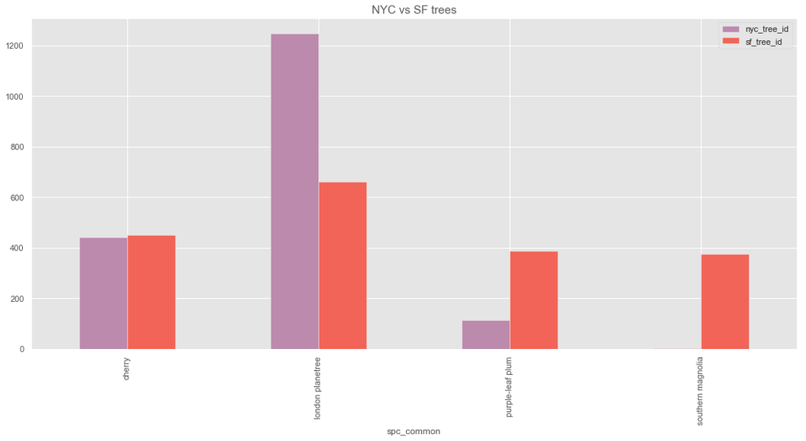

```python
rcParams['figure.figsize'] = 18, 8
rcParams['font.size'] = 25

plt.style.use('ggplot')
m_plot.loc[:,['nyc_tree_id','sf_tree_id']].plot(kind='bar', color=['#bc8aad', '#F26458'])
plt.title('NYC vs SF trees', alpha=1.75, fontsize=15)
```

## Analysis of the NYC Tree Census 2015

- Overview of the general tree population by boroughs
- Analysis of the top species distribution by boroughs
- Analysis of the diameter size of the top five most common species
- Overview of the overall health of the species by boroughs
- Mapping location of the species base on the coordinates of drawn sample

### Overview of general tree population by boroughs

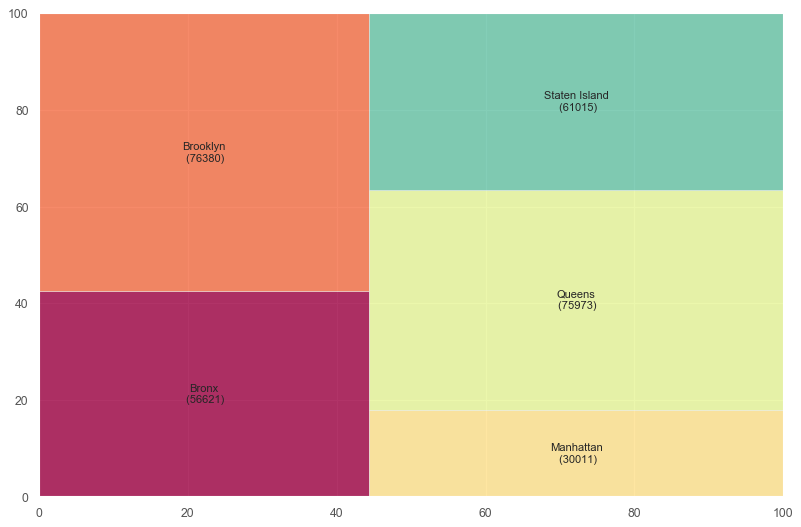

```python
# Preparing Data
df = df_api.groupby('boroname').size().reset_index(name='counts')
labels = df.apply(lambda x: str(x[0]) + "\n (" + str(x[1]) + ")", axis=1)
sizes = df['counts'].values.tolist()
colors = [plt.cm.Spectral(i/float(len(labels))) for i in range(len(labels))]

plt.figure(figsize=(12,8), dpi= 80)
squarify.plot(sizes=sizes, label=labels, color=colors, alpha=.8)
#https://www.machinelearningplus.com/plots/top-50-matplotlib-visualizations-the-master-plots-python/
#33. Treemap
```

As we can observe from above plot, Queens and Brooklyn are most populated boroughs with trees and make up roughly 51% of total observed population of the species of our sample. Smallest amount of observations reported in Manhattan , although Manhattan is third largest populated borough of NYC with slightly more than 1.6 million residents, this may be explained with high density of the buildings, Brooklyn second with 2.5 million and Queens third with roughly 2.3 million residents.

Resident data according to 2018 Census. Retrieved from: https://www.citypopulation.de/php/usa-newyorkcity.php

```python
df_aw = df_api.groupby('spc_common')['tree_id'].nunique().nlargest(30)
df_aw
```

```
spc_common
London planetree          36919
honeylocust               27956
Callery pear              27478
pin oak                   21437
Norway maple              15567
cherry                    13077
Japanese zelkova          12781
littleleaf linden         12321
ginkgo                     9241
Sophora                    8733
red maple                  8660
green ash                  6559
American linden            6141
silver maple               5266
sweetgum                   4890
American elm               3579
northern red oak           3506
purple-leaf plum           3349
swamp white oak            2739
Chinese elm                2668
maple                      2611
silver linden              2484
'Schubert' chokecherry     2349
crimson king maple         2304
Japanese tree lilac        2036
golden raintree            1940
eastern redbud             1896
crab apple                 1751
willow oak                 1513
hedge maple                1503
Name: tree_id, dtype: int64
```

For further analysis purposes above table, represents amount of most common species in our observation.

### Analysis of the top ten species distribution by boroughs

```python
df_top = df_api.loc[df_api['spc_common'].isin(['London planetree','honeylocust','Callery pear','pin oak','Norway maple','cherry','Japanese zelkova','littleleaf linden','ginkgo','Sophora'])]
df_top['spc_common'] = df_top['spc_common'].str.lower()
```

```python
df_rapi1 = pd.crosstab(df_top.boroname, df_top.spc_common, margins= True)
df_rapi1
```

| spc_common boroname | callery pear | cherry | ginkgo | honeylocust | japanese zelkova | littleleaf linden | london planetree | norway maple | pin oak | sophora | All |
| --- | --- | --- | --- | --- | --- | --- | --- | --- | --- | --- | --- |
| Bronx | 3395 | 2801 | 1759 | 6495 | 3066 | 2565 | 5193 | 2496 | 4280 | 1756 | 33806 |
| Brooklyn | 3740 | 2938 | 2337 | 6747 | 3998 | 3651 | 14816 | 3485 | 5046 | 2634 | 49392 |
| Manhattan | 3173 | 270 | 2810 | 6178 | 1580 | 1497 | 1789 | 137 | 2013 | 1968 | 21415 |
| Queens | 5174 | 3956 | 1780 | 5951 | 2678 | 3522 | 9082 | 7042 | 5812 | 1877 | 46874 |
| Staten Island | 11996 | 3112 | 555 | 2585 | 1459 | 1086 | 6039 | 2407 | 4286 | 498 | 34023 |
| All | 27478 | 13077 | 9241 | 27956 | 12781 | 12321 | 36919 | 15567 | 21437 | 8733 | 185510 |

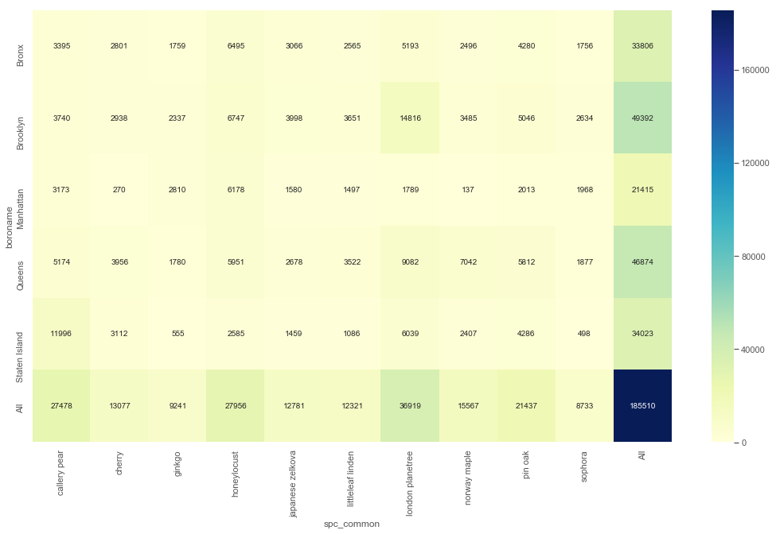

```python
fig, ax = plt.subplots(figsize=(18,10))
sns.heatmap(df_rapi1, cmap="YlGnBu", annot=True, fmt="d",  ax=ax)
```

Above graph represents breakdown of the NYC tree agglomeration by boroughs based on top 10 species and rep sample of 300 thousand observation. As it was discussed earlier, London Plane tree is most common species out of our sample and highest population located in Brooklyn with almost 15 thousand recorded observations, followed by Callery Pear located in Staten Island with roughly 12 thousand observations.

### Analysis of the diameter size of the top five most common species

During preliminary overview of the data set , it was noted that some observations had significantly larger diameter (DBH ) of the trunk size. Performed basic outlier detection procedures, tree with DBH greater than >60 cm eliminated.

```python
df_api.index
```

```
RangeIndex(start=0, stop=300000, step=1)
```

```python
df_mean = df_api.loc[df_api['spc_common'].isin(['London planetree','honeylocust','Callery pear','pin oak','Norway maple'])]
```

```python
df_mean.head(5)
```

|  | address | boroname | curb_loc | guards | health | latitude | longitude | nta_name | problems | spc_common | spc_latin | state | status | tree_dbh | tree_id | trunk_wire | x_sp | y_sp | zip_city | zipcode |
| --- | --- | --- | --- | --- | --- | --- | --- | --- | --- | --- | --- | --- | --- | --- | --- | --- | --- | --- | --- | --- |
| 1 | 147-074 7 AVENUE | Queens | OnCurb | None | Fair | 40.794111 | -73.818679 | Whitestone | Stones | pin oak | Quercus palustris | New York | Alive | 21 | 200540 | No | 1.034456e+06 | 228644.8374 | Whitestone | 11357 |
| 2 | 390 MORGAN AVENUE | Brooklyn | OnCurb | None | Good | 40.717581 | -73.936608 | East Williamsburg | None | honeylocust | Gleditsia triacanthos var. inermis | New York | Alive | 3 | 204026 | No | 1.001823e+06 | 200716.8913 | Brooklyn | 11211 |
| 3 | 1027 GRAND STREET | Brooklyn | OnCurb | None | Good | 40.713537 | -73.934456 | East Williamsburg | Stones | honeylocust | Gleditsia triacanthos var. inermis | New York | Alive | 10 | 204337 | No | 1.002420e+06 | 199244.2531 | Brooklyn | 11211 |
| 5 | 8 COLUMBUS AVENUE | Manhattan | OnCurb | Helpful | Good | 40.770046 | -73.984950 | Lincoln Square | None | honeylocust | Gleditsia triacanthos var. inermis | New York | Alive | 11 | 190422 | No | 9.884187e+05 | 219825.5227 | New York | 10023 |
| 6 | 120 WEST 60 STREET | Manhattan | OnCurb | Helpful | Good | 40.770210 | -73.985338 | Lincoln Square | None | honeylocust | Gleditsia triacanthos var. inermis | New York | Alive | 11 | 190426 | No | 9.883112e+05 | 219885.2785 | New York | 10023 |

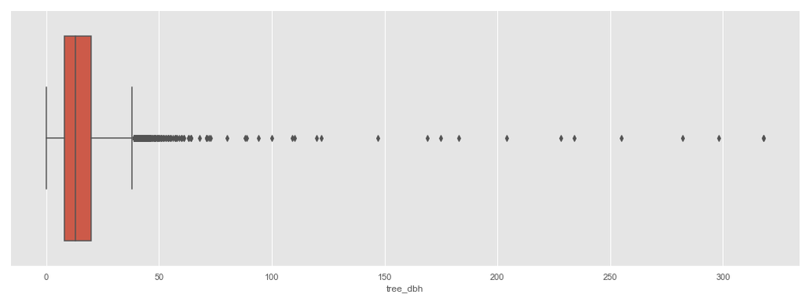

```python
plt.figure(figsize=(18, 6))
sns.boxplot(x=df_mean['tree_dbh'])
```

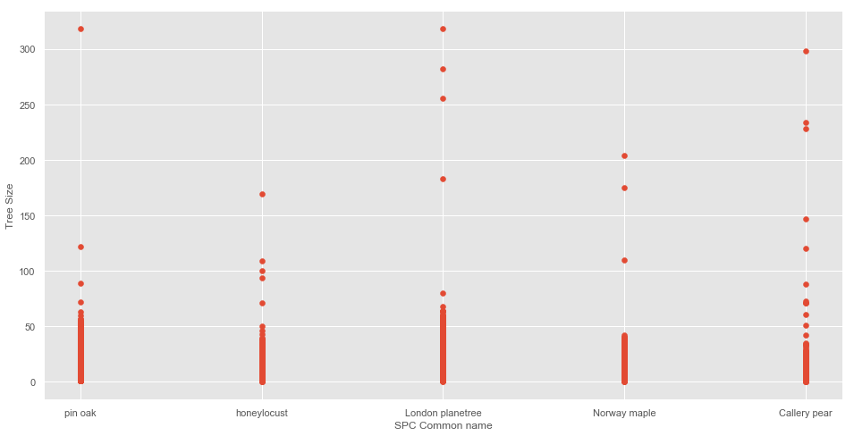

```python
fig, ax = plt.subplots(figsize=(16,8))
ax.scatter(df_mean['spc_common'], df_mean['tree_dbh'])
ax.set_xlabel('SPC Common name')
ax.set_ylabel('Tree Size')
plt.show()
```

```python
df_mean.drop(df_mean[ df_mean['tree_dbh'] >= 60].index , inplace=True)
df_mean.describe()
```

|  | latitude | longitude | tree_dbh | x_sp | y_sp | zipcode |
| --- | --- | --- | --- | --- | --- | --- |
| count | 129319.000000 | 129319.000000 | 129319.00000 | 1.293190e+05 | 129319.000000 | 129319.000000 |
| mean | 40.696850 | -73.946267 | 14.58699 | 9.991154e+05 | 193188.791780 | 10804.477749 |
| std | 0.100946 | 0.129126 | 8.65722 | 3.582568e+04 | 36775.042434 | 610.274034 |
| min | 40.498510 | -74.254432 | 0.00000 | 9.134969e+05 | 120989.630100 | 83.000000 |
| 25% | 40.613574 | -73.994756 | 8.00000 | 9.857030e+05 | 162829.314000 | 10312.000000 |
| 50% | 40.692852 | -73.930817 | 13.00000 | 1.003426e+06 | 191746.680200 | 11101.000000 |
| 75% | 40.768642 | -73.858428 | 20.00000 | 1.023457e+06 | 219343.937550 | 11235.000000 |
| max | 40.910883 | -73.700488 | 59.00000 | 1.067248e+06 | 271154.286500 | 11694.000000 |

Elimination of outliers at 60 cm gives better overall distribution of the population DBH size.

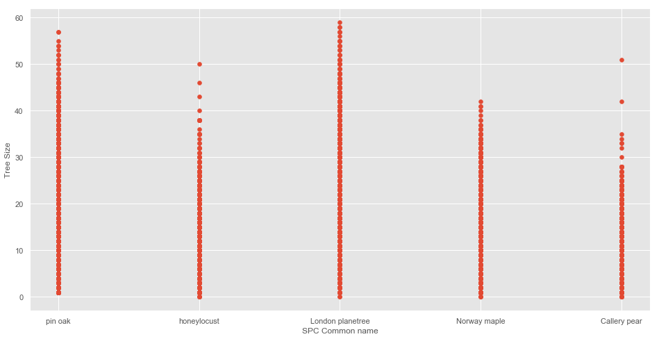

```python
fig, ax = plt.subplots(figsize=(16,8))
ax.scatter(df_mean['spc_common'], df_mean['tree_dbh'])
ax.set_xlabel('SPC Common name')
ax.set_ylabel('Tree Size')
plt.show()
```

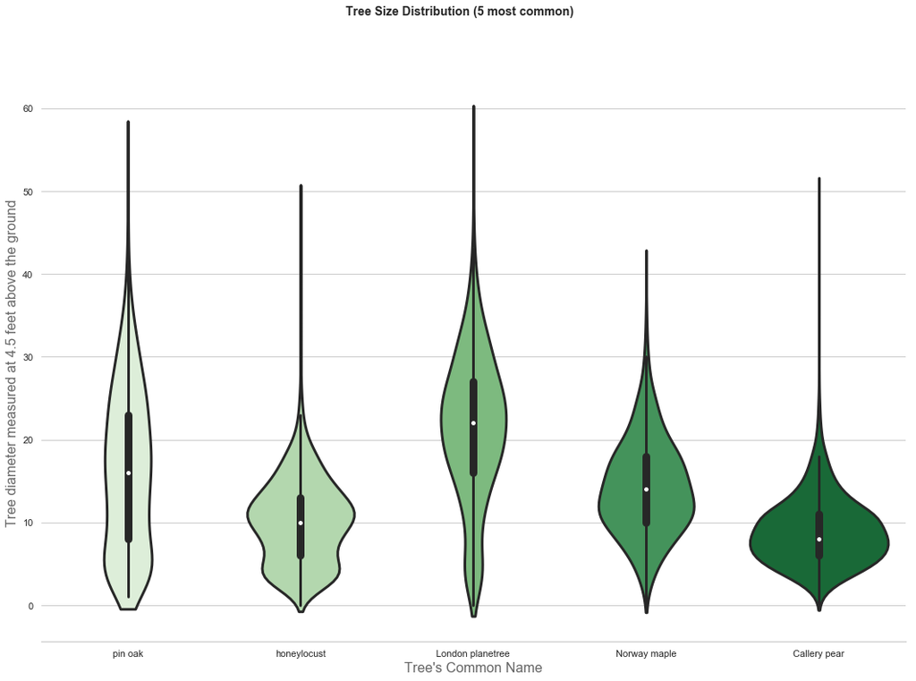

```python
sns.set(style="whitegrid")
df = df_mean

f, ax = plt.subplots(figsize=(18, 12))
sns.violinplot(x="spc_common",y="tree_dbh",data=df, inner="box", palette="Greens",  bw =.3, cut=.5, linewidth=3)

sns.despine(left=True)

f.suptitle('Tree Size Distribution (5 most common)', fontsize=14, fontweight='bold')
ax.set_xlabel("Tree's Common Name",size = 16,alpha=0.7)
ax.set_ylabel("Tree diameter measured at 4.5 feet above the ground ",size = 16,alpha=0.7)

#Retrieved from https://mode.com/blog/violin-plot-examples
```

According to resources Largest tree of the representative sample The London plane is a large deciduous tree growing 20–30 m (66–98 ft), exceptionally over 40 m (131 ft) tall, with a trunk up to 3 m (10 ft) or more in circumference. Smallest is; Callery Pear or Pyrus calleryana is deciduous, growing to 5 to 8 m (16 to 26 ft) tall, often with a conical to rounded crown. Above graph represents overall DBH size distribution of top 5 species. Overall graph in line with assumptions from the resources, London plane tree is the biggest and tallest and callery pear is the smallest ouf our representative sample.

Resource: https://en.wikipedia.org/wiki/Pyrus_calleryana Resource: https://en.wikipedia.org/wiki/Platanus_×_acerifolia

### Overview of the overall health of representative sample

```python
#df_api.groupby('boroname')['health'].unique()
#df_api.groupby('boroname')['health'].count()
df_h = df_api.groupby(['boroname', 'health']).size().reset_index(name='counts')
df_h
```

|  | boroname | health | counts |
| --- | --- | --- | --- |
| 0 | Bronx | Fair | 6847 |
| 1 | Bronx | Good | 44362 |
| 2 | Bronx | Poor | 2163 |
| 3 | Brooklyn | Fair | 11053 |
| 4 | Brooklyn | Good | 58229 |
| 5 | Brooklyn | Poor | 3528 |
| 6 | Manhattan | Fair | 5361 |
| 7 | Manhattan | Good | 21181 |
| 8 | Manhattan | Poor | 2039 |
| 9 | Queens | Fair | 12920 |
| 10 | Queens | Good | 54994 |
| 11 | Queens | Poor | 4143 |
| 12 | Staten Island | Fair | 7193 |
| 13 | Staten Island | Good | 49506 |
| 14 | Staten Island | Poor | 2081 |

```python
df_h.dtypes
```

```
boroname    object
health      object
counts       int64
dtype: object
```

```python
plotly.tools.set_credentials_file(username='Beka777', api_key='8yBfbotYmct42lRf6gCB')
offline.init_notebook_mode(connected=True)
```

```python
import plotly.offline as pyo
from plotly.offline import download_plotlyjs, init_notebook_mode, plot, iplot
init_notebook_mode(connected=True)
```

```python
df_zz = pd.crosstab(df_api.boroname, df_api.health, margins= True)
df_zz.dtypes
```

```
health
Fair    int64
Good    int64
Poor    int64
All     int64
dtype: object
```

```python
#df_zz = df_zz.drop(columns="All")
#df_zz = df_zz.drop("All", axis=0)
df_plotly = df_zz
df_plotly
```

| health boroname | Fair | Good | Poor | All |
| --- | --- | --- | --- | --- |
| Bronx | 6847 | 44362 | 2163 | 53372 |
| Brooklyn | 11053 | 58229 | 3528 | 72810 |
| Manhattan | 5361 | 21181 | 2039 | 28581 |
| Queens | 12920 | 54994 | 4143 | 72057 |
| Staten Island | 7193 | 49506 | 2081 | 58780 |
| All | 43374 | 228272 | 13954 | 285600 |

```python
df_plotly = df_plotly.drop("All", axis=0)
```

```python
trace0 = go.Bar(
    x = df_plotly.index,
    y = df_plotly.Good,
    marker=dict(
        color='#3ACB5B'),
    name='Good'
)

trace1 = go.Bar(
    x = df_plotly.index,
    y = df_plotly.Fair,
        marker=dict(
        color='#609E64'),
    name='Fair'
)

trace2 = go.Bar(
    x = df_plotly.index,
    y = df_plotly.Poor,
        marker=dict(
        color='#B97D66'),
    name='Poor'
)

traces= [go.Scatter(
    x = df_plotly.columns,
    y = df_plotly.loc[rowname],
    mode = 'markers+lines',
    name = 'xxx'
) for rowname in df_plotly.index]

data = [trace0, trace1, trace2]
layout = go.Layout(
    barmode='stack',  title='Trees Health Status by Borough')
fig = go.Figure(data=data, layout=layout)
pyo.offline.iplot(fig, filename='stacked-bar')

#Source retrieved from: https://plot.ly/python/bar-charts/
```

[interactive chart not shown]

Above graph represents overall overview of presumed health status of the tree population, graph was generated based on Plotly library, and include dynamic columns. Based on the summary output of cross tabulation function, we are able to conclude that roughly 80% or 228 thousand trees are in presumably Good Health condition. Representative sample consist of 300 thousand observation and conclusion was drawn based on 285 thousand observation, all others were dropped due to missing observations

### Mapping location of the species base on the coordinates of drawn sample

```python
import gmaps
import gmaps.datasets
```

```python
random_api = df_api.sample(n=10000)
print(random_api.head())
```

```
                      address       boroname curb_loc guards health  \
209309    1337 EAST 29 STREET       Brooklyn   OnCurb   None   Good
16903   300 WEST SERVICE ROAD  Staten Island   OnCurb   None   Poor
115962       2575 FISH AVENUE          Bronx   OnCurb    NaN    NaN
294086        74 ADLAI CIRCLE  Staten Island   OnCurb   None   Good
117097          373 11 STREET       Brooklyn   OnCurb   None   Good

         latitude  longitude                                    nta_name  \
209309  40.618539 -73.946270                                   Flatlands
16903   40.585771 -74.193796           New Springville-Bloomfield-Travis
115962  40.864909 -73.847263                     Allerton-Pelham Gardens
294086  40.544407 -74.173142  Annadale-Huguenot-Prince's Bay-Eltingville
117097  40.667320 -73.985843                          Park Slope-Gowanus

            problems         spc_common           spc_latin     state status  \
```

[output cut: 19 more lines]

```python
gmaps.configure("AIzaSyANVf8cXZ3KusFgBAnLuiaQcO6i9eVN3ZU") #personal key
fig = gmaps.figure(map_type="HYBRID", center=(40.706742, -73.816493), zoom_level=10,
                  layout={
        'width': '1200px',
        'height': '600px',
        'padding': '3px',
        'border': '1px solid black'
})
locations = df_api[['latitude', 'longitude']]
heatmap = gmaps.heatmap_layer(locations)
heatmap.max_intensity = 2
heatmap.point_radius = 2
heatmap.gradient = ['white', 'green']
fig.add_layer(heatmap)
fig
#Data retreived: https://jupyter-gmaps.readthedocs.io/en/latest/api.html
```

Please make sure to place html file and included MapLocation.png in to one folder before you open html file. Thank you.

[figure not shown]

To exercise plotting coordinates of NYC tree census data, two different techniques were selected, based on Google map (gmap) and Seaborn libraries. Based on the documentation and dynamic nature of the Gmap, to visualize the map it must be run at given time, only possible way to save the output in html is to print screen the output and to upload it in to the python (which was done). Also, based on the existing coordinates, seaborn plot was produced (based on the sample of 10 thousand observations), which pretty accurately imitates the map of five boroughs of NYC.

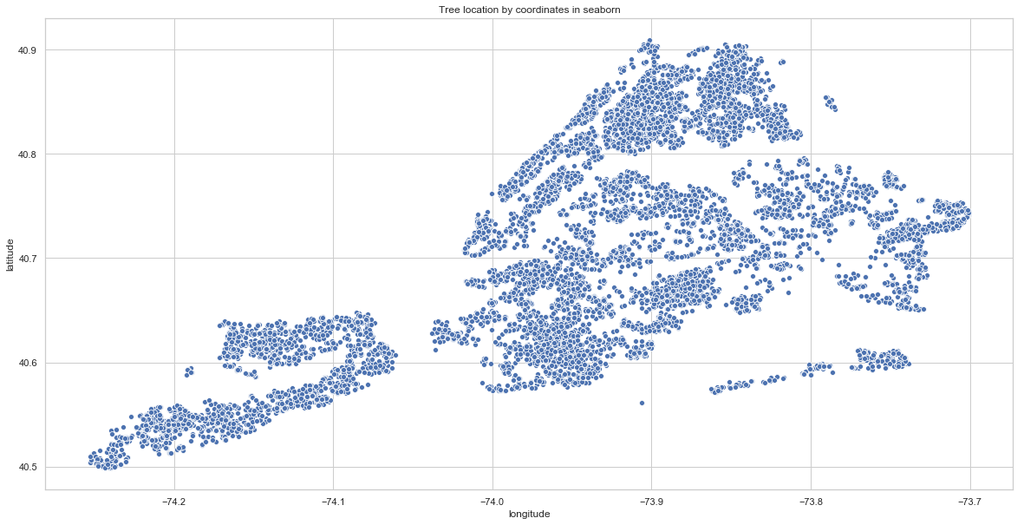

```python
tree_df = df_api
plt.figure(figsize=[20,10])
sns.scatterplot(x='longitude', y='latitude', palette="YlGnBu", data=tree_df.sample(10000)).set_title('Tree location by coordinates in seaborn');

#retrieved from:  https://seaborn.pydata.org/introduction.html
```

## Data persistence into 2 different formats (SQLite, HDF5)

```python
# Create a database in RAM
connection = sqlite3.connect(':memory:')
# Creates or opens a file called mySQLiteDB.sl3 with a SQLite3 DB
connection = sqlite3.connect('../datasets/mySQLiteDB.sl3')
cursor = connection.cursor()
#Codes Retrieved from Lecture (#14) notes. Lecturer: Rachel Owen.
```

```python
cursor.execute("DROP TABLE IF EXISTS df_api")
df_api.to_sql(name='df_api', con=connection)
#Code Retrieved from: https://stackoverflow.com/questions/14431646/how-to-write-pandas-dataframe-to-sqlite-with-index
```

```python
df_sql = pd.read_sql('select spc_common from df_api', connection)
```

```python
df_sql.head(10)
```

|  | spc_common |
| --- | --- |
| 0 | red maple |
| 1 | pin oak |
| 2 | honeylocust |
| 3 | honeylocust |
| 4 | American linden |
| 5 | honeylocust |
| 6 | honeylocust |
| 7 | American linden |
| 8 | honeylocust |
| 9 | London planetree |

```python
df_plotly.to_hdf('data.h5', key='df_plotly', mode='w')
```

Above exercise demonstrates data persistence skills in two formats, SQLite and HDF5.

## Conclusion

Above data sets from various resources provide good opportunity to demonstrate implementation of a full data analysis workflow based on but not limited to: data acquisition, data wrangling, data integration, data persistence and data analysis using Python. Multiple interesting variables allow to draw conclusion based on numerous angles of the data. I truly admire, how much effort was involved in to gathering this data, and considering continuity of the Tree Census data, above analysis may be interesting entry point in to casual analysis of the overall Tree Park of the New York City.